# Plotting dendrograms

Robyn Seymour-Jones

04/12/2020

## Introduction

It is proving difficult to plot a dendrogram for my diatom record as it contains missing samples (some completely missing because of a misplaced section of the sediment core and some where there were no diatoms present). The document explores the various options for plotting dendrograms in R.

I want to add the dendrogram to the right of my stratigraphic plot, which I am plotting with ggplot and the help of the tidypaleo package. Therefore, I ideally want to plot the dendrogram with ggplot too.

## Load requirements

```r
library(rioja)
library(ggplot2)
library(ggdendro)
source("scripts/borders-for-ggplot2.R")
source("scripts/02-manipulate.R")
```

## Prepare data and run cluster analysis

```r
# Prepare data for analysis
coniss_data <- taxa$counts %>%
  # isolate taxa present at ≥4 %
  transmute(
    sample_no = sample_no,
    select(., all_of(abundant_taxa(taxa$rel_ab, 4)))
  ) %>%
  # convert to proportion based on only these abundant taxa
  mutate(
    sample_no = sample_no,
    decostand(select(., -sample_no),
              method = "total",
              na.rm = "TRUE")
  ) %>%
  # replace sample numbers with depths
  mutate(
    depth = imported$depths$depth,
    sample_no = NULL
  ) %>%
  # remove samples with no diatoms
  column_to_rownames("depth") %>%
  filter(., rowSums(.) > 0) %>%
  # square-root transform
  sqrt() %>%
  # remove outlier
  rownames_to_column("depth") %>%
  mutate(depth = as.numeric(depth)) %>%
  slice(., -44) %>%
  column_to_rownames("depth")

# Calculate distance matrix
dist_matrix <- designdist(coniss_data, method = "A+B-2*J", terms = "quadratic")

# Run cluster analysis
coniss_results <- chclust(dist_matrix, method = "coniss")
```

## Plotting with `plot.chclust()`

I have successfully managed to plot the dendrogram I am after through the `plot.chclust()` method from the rioja package. Although this is what I am after, it is not ideal as my other plots are created with ggplot and it makes it difficult to combine them in to one plot.

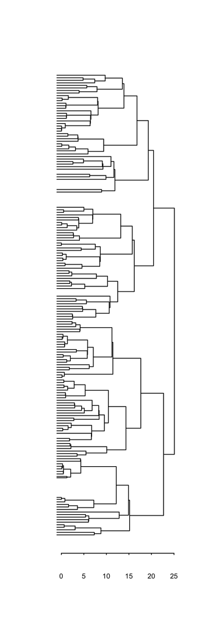

```r
# Isolate depths
coniss_depths <- coniss_data %>%
  rownames_to_column("depth") %>%
  mutate(depth = as.numeric(depth)) %>%
  select(., "depth")

# Plot
plot(
  coniss_results,
  hang = -1, # make leaves extend to 0 and labels hang down from there
  horiz = TRUE, # display plot vertically (depths now "x-axis")
  x.rev = TRUE, # reverse depths
  xvar = coniss_depths$depth, # plot samples by depth rather than just sequential order
  labels = FALSE, # remove leaf labels
  cex.axis = 0.6,
  tcl = -0.1
)
```

There are a few other problems with this plot. I can’t plot the axis label (it should be “Total sum of squares”). Also, the leaves extend to the left of the 0 but I would ideally want them to stop at 0. It doesn’t seem to do this in the examples I have seen elsewhere.

## Plotting with the ggdendro package

This is the first way I plotted my dendrograms but I just couldn’t figure out how to plot the leaves/segments by depth rather than just in sequential order. I think it would require some sort of alteration to the `dendro_data()` function in order to extract values for the segments that are aligned with the depths rather than just in order. This is something I just don’t have the time to try to explore.

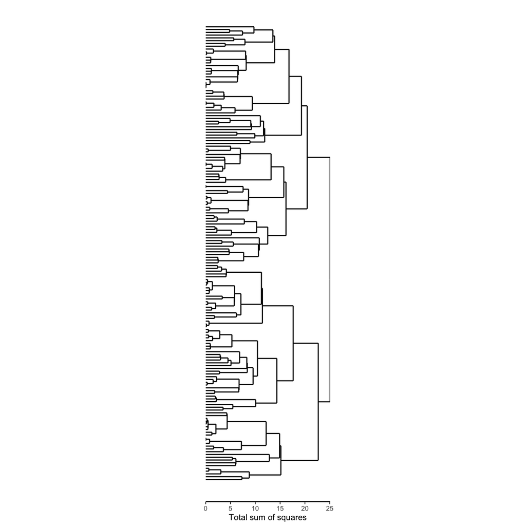

```r
# Extract dendrogram data
ddata <- dendro_data(coniss_results, type = "rectangle")

# Plot
ggplot(segment(ddata)) +
  geom_segment(aes(x = x, y = y, xend = xend, yend = yend)) +
  coord_flip() +
  scale_y_continuous(expand = c(0, 0)) +
  scale_x_reverse(breaks = NULL,
                  labels = NULL) +
  labs(x = "",
       y = "Total sum of squares") +
  theme_bw(8) +
  theme(aspect.ratio = 4,
        legend.position = "none",
        panel.grid = element_blank(),
        panel.border = theme_border("bottom"),
        panel.background = element_rect(fill = "transparent"),
        plot.background = element_rect(fill = "transparent"))
```

This is exactly how I want the dendrogram to display, except that I want it with the gaps that are present in the version created with `plot.chclust()`.

## Solution from a hero on Stack Overflow

I just could not figure out to plot the dendrogram leaves by depth so I posted my first ever question on Stack Overflow. I didn’t think I would get a reply but I got one with 10 minutes! I had been reluctant to ask a question on there as I knew I had to write out the question really clearly and provide example data and examples of what I want to achieve. I just thought it would take too long and migtht not get a reply. I can’t believe how easy it was and how helpful. Here is the soloution. It is only three lines of code that was causing me all this stress!

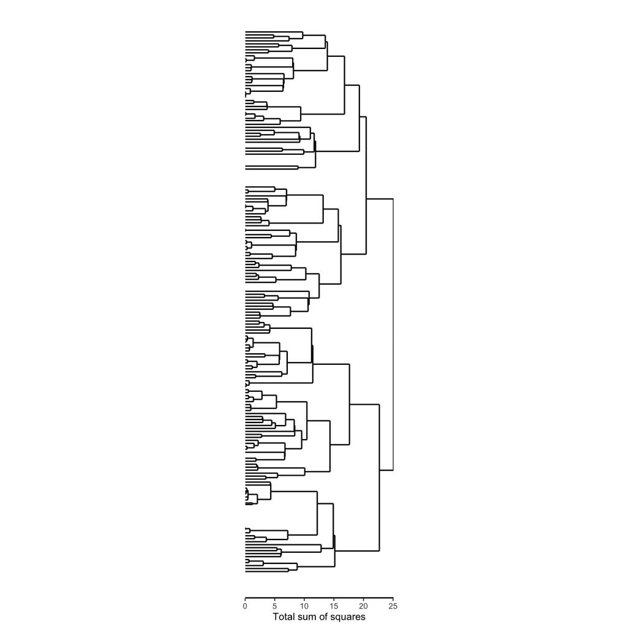

```r
# Map depths to x values
new_x <- approxfun(ddata$labels$x, as.numeric(as.character(ddata$labels$label)))
ddata$segments$x <- new_x(ddata$segments$x)
ddata$segments$xend <- new_x(ddata$segments$xend)

# Plot (same as previous)
ggplot(segment(ddata)) +
  geom_segment(aes(x = x, y = y, xend = xend, yend = yend)) +
  coord_flip() +
  scale_y_continuous(expand = c(0, 0)) +
  scale_x_reverse(breaks = NULL,
                  labels = NULL) +
  labs(x = "",
       y = "Total sum of squares") +
  theme_bw(8) +
  theme(aspect.ratio = 4,
        legend.position = "none",
        panel.grid = element_blank(),
        panel.border = theme_border("bottom"),
        panel.background = element_rect(fill = "transparent"),
        plot.background = element_rect(fill = "transparent"))
```